# linear R

```r
library(dplyr)
crime <- read.csv("crime.csv") %>%
dplyr::select(-X)
names(crime) <- c("percent_m", "is_south", "mean_education", "police_exp60", "police_exp59", "labour_participation", "m_per1000f", "state_pop", "nonwhites_per1000", "unemploy_m24", "unemploy_m39", "gdp", "inequality", "prob_prison", "time_prison", "crime_rate")
```

try set a linear model of crime_rate by using all of the variables, and try to identify highly correlated data in the model.

```r
library(car)
crime_model <- lm(crime_rate ~ ., crime)
crime_exp <- lm(crime_rate ~ police_exp59 + police_exp60, crime)
vif(crime_model)
```

```
##            percent_m             is_south       mean_education
##             2.892448             5.342783             5.077447
##         police_exp60         police_exp59 labour_participation
##           104.658667           113.559262             3.712690
##           m_per1000f            state_pop    nonwhites_per1000
##             3.785934             2.536708             4.674088
##         unemploy_m24         unemploy_m39                  gdp
##             6.063931             5.088880            10.530375
##           inequality          prob_prison          time_prison
##             8.644528             2.809459             2.713785
```

```r
vif(crime_exp)
```

```
## police_exp59 police_exp60
##     78.21115     78.21115
```

police_exp59 and police_exp60 are highly corralated, so we use feature engineering to capture both data and combine them in police_exp by finding the means.

```r
crime$police_exp <- (crime$police_exp59 + crime$police_exp60)/2
newcrime <- subset(crime, select=-c(police_exp59, police_exp60))
```

try to check if there’re another highly correlated data.

```r
crime_model <- lm(crime_rate ~., newcrime)
vif(crime_model)
```

```
##            percent_m             is_south       mean_education
##             2.887155             5.329859             4.916133
## labour_participation           m_per1000f            state_pop
##             3.479376             3.763639             2.536678
##    nonwhites_per1000         unemploy_m24         unemploy_m39
##             4.397337             6.040838             5.075819
##                  gdp           inequality          prob_prison
##            10.528833             8.577985             2.632507
##          time_prison           police_exp
##             2.417413             5.608804
```

```r
summary(crime_model)
```

```
##
## Call:
## lm(formula = crime_rate ~ ., data = newcrime)
##
## Residuals:
##     Min      1Q  Median      3Q     Max
## -459.84 -122.87   11.49  117.58  451.50
##
## Coefficients:
##                        Estimate Std. Error t value Pr(>|t|)
## (Intercept)          -6606.4737  1583.4238  -4.172 0.000215 ***
## percent_m                9.0258     4.2226   2.137 0.040298 *
## is_south                 6.1504   150.5377   0.041 0.967664
## mean_education          17.3268     6.1901   2.799 0.008612 **
## labour_participation    -0.1626     1.4416  -0.113 0.910921
## m_per1000f               1.9532     2.0562   0.950 0.349278
## state_pop               -0.7269     1.3066  -0.556 0.581830
## nonwhites_per1000        0.2059     0.6369   0.323 0.748596
## unemploy_m24            -5.4736     4.2578  -1.286 0.207824
## unemploy_m39            17.3475     8.3316   2.082 0.045411 *
## gdp                      0.9446     1.0503   0.899 0.375170
## inequality               7.3384     2.2928   3.201 0.003091 **
## prob_prison          -4079.3771  2228.7052  -1.830 0.076521 .
## time_prison             -0.2575     6.8520  -0.038 0.970261
## police_exp               9.8949     2.5688   3.852 0.000530 ***
## ---
## Signif. codes:  0 '***' 0.001 '**' 0.01 '*' 0.05 '.' 0.1 ' ' 1
##
## Residual standard error: 211.8 on 32 degrees of freedom
## Multiple R-squared:  0.7913, Adjusted R-squared:    0.7
## F-statistic: 8.668 on 14 and 32 DF,  p-value: 2.605e-07
```

there’re many variables that have Significance more than 0.05 we can eliminate the variables by using backward elimination, foward step-wise regression, and step-wise regression.

```r
step(crime_model, direction="backward")
```

```
## Start:  AIC=515.37
## crime_rate ~ percent_m + is_south + mean_education + labour_participation +
##     m_per1000f + state_pop + nonwhites_per1000 + unemploy_m24 +
##     unemploy_m39 + gdp + inequality + prob_prison + time_prison +
##     police_exp
##
##                        Df Sum of Sq     RSS    AIC
## - time_prison           1        63 1435912 513.38
## - is_south              1        75 1435924 513.38
## - labour_participation  1       571 1436420 513.39
## - nonwhites_per1000     1      4689 1440538 513.53
## - state_pop             1     13889 1449738 513.83
## - gdp                   1     36295 1472144 514.55
## - m_per1000f            1     40488 1476337 514.68
## <none>                              1435849 515.37
## - unemploy_m24          1     74155 1510004 515.74
## - prob_prison           1    150328 1586178 518.05
## - unemploy_m39          1    194523 1630372 519.35
## - percent_m             1    205006 1640855 519.65
## - mean_education        1    351558 1787407 523.67
## - inequality            1    459655 1895504 526.43
## - police_exp            1    665754 2101603 531.28
##
## Step:  AIC=513.38
## crime_rate ~ percent_m + is_south + mean_education + labour_participation +
##     m_per1000f + state_pop + nonwhites_per1000 + unemploy_m24 +
##     unemploy_m39 + gdp + inequality + prob_prison + police_exp
##
##                        Df Sum of Sq     RSS    AIC
## - is_south              1        94 1436006 511.38
## - labour_participation  1       573 1436486 511.40
## - nonwhites_per1000     1      4696 1440608 511.53
## - state_pop             1     15376 1451289 511.88
## - gdp                   1     36439 1472351 512.55
## - m_per1000f            1     42048 1477960 512.73
## <none>                              1435912 513.38
## - unemploy_m24          1     74740 1510652 513.76
## - unemploy_m39          1    196871 1632783 517.42
## - prob_prison           1    203777 1639689 517.61
## - percent_m             1    210715 1646627 517.81
```

[output cut: 76 more lines]

```
##
## Step:  AIC=505.13
## crime_rate ~ percent_m + mean_education + m_per1000f + unemploy_m24 +
##     unemploy_m39 + inequality + prob_prison + police_exp
##
##                  Df Sum of Sq     RSS    AIC
## <none>                        1490434 505.13
## - m_per1000f      1    117843 1608276 506.70
## - unemploy_m24    1    136366 1626799 507.24
## - prob_prison     1    256641 1747074 510.60
## - unemploy_m39    1    271328 1761761 510.99
## - percent_m       1    292207 1782641 511.54
## - mean_education  1    433030 1923464 515.12
## - inequality      1    744855 2235288 522.18
## - police_exp      1   1634672 3125105 537.93
```

```
##
## Call:
## lm(formula = crime_rate ~ percent_m + mean_education + m_per1000f +
##     unemploy_m24 + unemploy_m39 + inequality + prob_prison +
##     police_exp, data = newcrime)
##
## Coefficients:
##    (Intercept)       percent_m  mean_education      m_per1000f
##      -6541.179           9.258          17.775           2.383
##   unemploy_m24    unemploy_m39      inequality     prob_prison
##         -6.294          19.257           6.180       -3858.651
##     police_exp
##         10.556
```

```r
lm.start <- lm(crime_rate ~ 1, newcrime)
step(lm.start, scope=list(lower=lm.start, upper=crime_model), direction="forward")
```

```
## Start:  AIC=561.02
## crime_rate ~ 1
##
##                        Df Sum of Sq     RSS    AIC
## + police_exp            1   3168330 3712597 534.02
## + gdp                   1   1340152 5540775 552.84
## + prob_prison           1   1257075 5623853 553.54
## + state_pop             1    783660 6097267 557.34
## + mean_education        1    717146 6163781 557.85
## + m_per1000f            1    314867 6566061 560.82
## <none>                              6880928 561.02
## + labour_participation  1    245446 6635482 561.32
## + inequality            1    220530 6660397 561.49
## + unemploy_m39          1    216354 6664573 561.52
## + time_prison           1    154545 6726383 561.96
## + is_south              1     56527 6824400 562.64
## + percent_m             1     55084 6825844 562.65
## + unemploy_m24          1     17533 6863395 562.90
## + nonwhites_per1000     1      7312 6873615 562.97
##
## Step:  AIC=534.02
## crime_rate ~ police_exp
##
##                        Df Sum of Sq     RSS    AIC
## + inequality            1    759855 2952743 525.26
## + percent_m             1    612966 3099632 527.54
## + m_per1000f            1    260696 3451901 532.60
## + nonwhites_per1000     1    232645 3479952 532.98
## + is_south              1    214795 3497803 533.22
## + gdp                   1    170207 3542390 533.82
## <none>                              3712597 534.02
## + prob_prison           1     99424 3613173 534.75
## + labour_participation  1     86340 3626257 534.92
## + time_prison           1     54647 3657950 535.33
## + unemploy_m39          1     22883 3689715 535.73
## + state_pop             1      2449 3710149 535.99
## + unemploy_m24          1      2269 3710328 535.99
## + mean_education        1      1064 3711533 536.01
##
## Step:  AIC=525.26
```

[output cut: 79 more lines]

```
## + nonwhites_per1000     1        29 1665194 508.34
##
## Step:  AIC=506.34
## crime_rate ~ police_exp + inequality + mean_education + prob_prison +
##     percent_m + unemploy_m39 + gdp
##
##                        Df Sum of Sq     RSS    AIC
## <none>                              1595683 506.34
## + state_pop             1     52319 1543364 506.77
## + unemploy_m24          1     40730 1554953 507.12
## + m_per1000f            1     30656 1565027 507.42
## + labour_participation  1     14263 1581420 507.91
## + is_south              1      6372 1589311 508.15
## + time_prison           1      5820 1589863 508.16
## + nonwhites_per1000     1      1206 1594477 508.30
```

```
##
## Call:
## lm(formula = crime_rate ~ police_exp + inequality + mean_education +
##     prob_prison + percent_m + unemploy_m39 + gdp, data = newcrime)
##
## Coefficients:
##    (Intercept)      police_exp      inequality  mean_education
##      -5807.418          10.518           8.228          18.104
##    prob_prison       percent_m    unemploy_m39             gdp
##      -3388.152          11.279           8.578           1.218
```

```r
step(lm.start, scope = list(upper=crime_model), data=newcrime, direction="both")
```

```
## Start:  AIC=561.02
## crime_rate ~ 1
##
##                        Df Sum of Sq     RSS    AIC
## + police_exp            1   3168330 3712597 534.02
## + gdp                   1   1340152 5540775 552.84
## + prob_prison           1   1257075 5623853 553.54
## + state_pop             1    783660 6097267 557.34
## + mean_education        1    717146 6163781 557.85
## + m_per1000f            1    314867 6566061 560.82
## <none>                              6880928 561.02
## + labour_participation  1    245446 6635482 561.32
## + inequality            1    220530 6660397 561.49
## + unemploy_m39          1    216354 6664573 561.52
## + time_prison           1    154545 6726383 561.96
## + is_south              1     56527 6824400 562.64
## + percent_m             1     55084 6825844 562.65
## + unemploy_m24          1     17533 6863395 562.90
## + nonwhites_per1000     1      7312 6873615 562.97
##
## Step:  AIC=534.02
## crime_rate ~ police_exp
##
##                        Df Sum of Sq     RSS    AIC
## + inequality            1    759855 2952743 525.26
## + percent_m             1    612966 3099632 527.54
## + m_per1000f            1    260696 3451901 532.60
## + nonwhites_per1000     1    232645 3479952 532.98
## + is_south              1    214795 3497803 533.22
## + gdp                   1    170207 3542390 533.82
## <none>                              3712597 534.02
## + prob_prison           1     99424 3613173 534.75
## + labour_participation  1     86340 3626257 534.92
## + time_prison           1     54647 3657950 535.33
## + unemploy_m39          1     22883 3689715 535.73
## + state_pop             1      2449 3710149 535.99
## + unemploy_m24          1      2269 3710328 535.99
## + mean_education        1      1064 3711533 536.01
## - police_exp            1   3168330 6880928 561.02
##
```

[output cut: 107 more lines]

```
## <none>                              1595683 506.34
## - gdp                   1     69540 1665223 506.34
## + state_pop             1     52319 1543364 506.77
## + unemploy_m24          1     40730 1554953 507.12
## + m_per1000f            1     30656 1565027 507.42
## + labour_participation  1     14263 1581420 507.91
## + is_south              1      6372 1589311 508.15
## + time_prison           1      5820 1589863 508.16
## + nonwhites_per1000     1      1206 1594477 508.30
## - unemploy_m39          1    174977 1770660 509.23
## - prob_prison           1    187398 1783081 509.55
## - percent_m             1    448351 2044033 515.97
## - mean_education        1    616660 2212343 519.69
## - inequality            1    892945 2488628 525.22
## - police_exp            1   1450148 3045831 534.72
```

```
##
## Call:
## lm(formula = crime_rate ~ police_exp + inequality + mean_education +
##     prob_prison + percent_m + unemploy_m39 + gdp, data = newcrime)
##
## Coefficients:
##    (Intercept)      police_exp      inequality  mean_education
##      -5807.418          10.518           8.228          18.104
##    prob_prison       percent_m    unemploy_m39             gdp
##      -3388.152          11.279           8.578           1.218
```

after using these three methods to eliminate some of the variables, now we can compare both results to see if there’re differences between these models.

```r
lm.back <- lm(formula = crime_rate ~ percent_m + mean_education + m_per1000f + unemploy_m24 + unemploy_m39 + inequality + prob_prison + police_exp, data = newcrime)
summary(lm.back)
```

```
##
## Call:
## lm(formula = crime_rate ~ percent_m + mean_education + m_per1000f +
##     unemploy_m24 + unemploy_m39 + inequality + prob_prison +
##     police_exp, data = newcrime)
##
## Residuals:
##     Min      1Q  Median      3Q     Max
## -475.87 -104.70    0.77  129.36  470.19
##
## Coefficients:
##                 Estimate Std. Error t value Pr(>|t|)
## (Intercept)    -6541.179   1210.687  -5.403 3.75e-06 ***
## percent_m          9.258      3.392   2.729  0.00956 **
## mean_education    17.775      5.350   3.323  0.00198 **
## m_per1000f         2.383      1.375   1.733  0.09114 .
## unemploy_m24      -6.294      3.375  -1.865  0.06997 .
## unemploy_m39      19.257      7.322   2.630  0.01226 *
## inequality         6.180      1.418   4.358 9.63e-05 ***
## prob_prison    -3858.651   1508.471  -2.558  0.01464 *
## police_exp        10.556      1.635   6.456 1.35e-07 ***
## ---
## Signif. codes:  0 '***' 0.001 '**' 0.01 '*' 0.05 '.' 0.1 ' ' 1
##
## Residual standard error: 198 on 38 degrees of freedom
## Multiple R-squared:  0.7834, Adjusted R-squared:  0.7378
## F-statistic: 17.18 on 8 and 38 DF,  p-value: 1.842e-10
```

```r
lm.fwdboth <- lm(formula = crime_rate ~ police_exp + inequality + mean_education + prob_prison + percent_m + unemploy_m39 + gdp, data = newcrime)
summary(lm.fwdboth)
```

```
##
## Call:
## lm(formula = crime_rate ~ police_exp + inequality + mean_education +
##     prob_prison + percent_m + unemploy_m39 + gdp, data = newcrime)
##
## Residuals:
##     Min      1Q  Median      3Q     Max
## -456.61  -94.58  -10.87  106.26  491.20
##
## Coefficients:
##                  Estimate Std. Error t value Pr(>|t|)
## (Intercept)    -5807.4184  1071.1423  -5.422 3.29e-06 ***
## police_exp        10.5179     1.7667   5.953 6.01e-07 ***
## inequality         8.2282     1.7613   4.672 3.51e-05 ***
## mean_education    18.1039     4.6633   3.882 0.000389 ***
## prob_prison    -3388.1521  1583.1465  -2.140 0.038655 *
## percent_m         11.2791     3.4073   3.310 0.002014 **
## unemploy_m39       8.5781     4.1480   2.068 0.045319 *
## gdp                1.2179     0.9342   1.304 0.199981
## ---
## Signif. codes:  0 '***' 0.001 '**' 0.01 '*' 0.05 '.' 0.1 ' ' 1
##
## Residual standard error: 202.3 on 39 degrees of freedom
## Multiple R-squared:  0.7681, Adjusted R-squared:  0.7265
## F-statistic: 18.45 on 7 and 39 DF,  p-value: 1.41e-10
```

if we take the variables that have Significance < 0.50 from both models(lm.back and lm.fwdboth) we get the same result with only 6 varibles (police_exp + inequality + mean_education + prob_prison + percent_m + unemploy_m39)

```r
lm.new <- lm(crime_rate ~ police_exp + inequality + mean_education + percent_m + prob_prison + unemploy_m39, newcrime)
summary(lm.new)
```

```
##
## Call:
## lm(formula = crime_rate ~ police_exp + inequality + mean_education +
##     percent_m + prob_prison + unemploy_m39, data = newcrime)
##
## Residuals:
##     Min      1Q  Median      3Q     Max
## -510.58  -94.22    2.86  137.87  544.92
##
## Coefficients:
##                 Estimate Std. Error t value Pr(>|t|)
## (Intercept)    -5066.925    916.051  -5.531 2.15e-06 ***
## police_exp        11.849      1.454   8.147 5.01e-10 ***
## inequality         6.851      1.422   4.819 2.11e-05 ***
## mean_education    19.645      4.550   4.318 0.000101 ***
## percent_m         10.515      3.386   3.106 0.003482 **
## prob_prison    -3872.294   1552.375  -2.494 0.016847 *
## unemploy_m39       9.237      4.153   2.224 0.031850 *
## ---
## Signif. codes:  0 '***' 0.001 '**' 0.01 '*' 0.05 '.' 0.1 ' ' 1
##
## Residual standard error: 204 on 40 degrees of freedom
## Multiple R-squared:  0.758,  Adjusted R-squared:  0.7217
## F-statistic: 20.88 on 6 and 40 DF,  p-value: 6.496e-11
```

in this model, the R-squared and adj.R-squared value are reduced a little but the all significance of variables is lower than 0.05. after all variables meet the requirements (R-value as close as possible to one, all the variables are significant, p-value < 0.05) now we can try to make sure there is no more systematic pattern in this model.

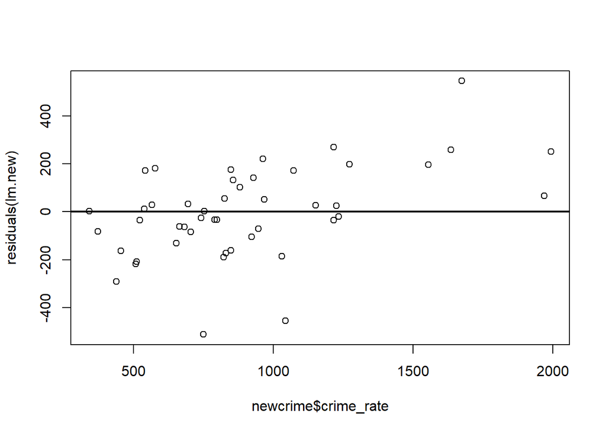

```r
plot(newcrime$crime_rate,residuals(lm.new))
abline(h=0, lwd=2)
```